# Feature Engineering

Variables in a dataset often contain valuable information that can be unlocked by extracting features. A single variable may generate one more features. On the other hand, a set of variables may be combined to form a single feature. It is these features that serve as inputs to machine learning models. The nature and types of transformation depend on whether the variable is categorical or numeric. We will first examine transformations for categorical variables before moving on to numeric variables.

```python
import pandas as pd
import numpy as np
import matplotlib.pyplot as plt
```

## Categorical Variables

A variable containing a set of discrete levels is said to be categorical. Other labels used to characterize this type of data include qualitative variable, non-metric variable and discrete variable. Given below are some examples of categorical variables.

```python
np.random.seed(1031)
gender = np.random.choice(['Male','Female'],size = 10,replace = True)
age_group = np.random.choice(['18-29','30-39','40-49','50-59','60 or over'],size = 10,replace=True)
marital_status = np.random.choice(['married','married','widowed','divorced','separated','never married','never married'],size = 10,replace = True)
ethnicity = np.random.choice(['White','Black','Native','Asian','Hispanic','Other'],size = 10,replace = True)
zip_code = np.random.randint(10000,10055,10)
cat_demo = pd.DataFrame({'gender':gender,
             'age_group':age_group,
             'marital_status': marital_status,
             'ethnicity': ethnicity,
             'zip_code': zip_code})
cat_demo
```

|  | gender | age_group | marital_status | ethnicity | zip_code |
| --- | --- | --- | --- | --- | --- |
| 0 | Female | 18-29 | divorced | Other | 10003 |
| 1 | Male | 30-39 | never married | Native | 10051 |
| 2 | Female | 30-39 | married | White | 10033 |
| 3 | Male | 60 or over | separated | Black | 10025 |
| 4 | Female | 18-29 | never married | White | 10023 |
| 5 | Male | 30-39 | widowed | White | 10036 |
| 6 | Male | 60 or over | married | Black | 10036 |
| 7 | Female | 18-29 | never married | White | 10033 |
| 8 | Female | 60 or over | never married | White | 10010 |
| 9 | Male | 30-39 | never married | Asian | 10001 |

Note the following characteristics of the variables:

1. gender takes on two non-numeric values
2. age_group has five age categories that are ordered. The values of age are in character form
3. marital status has five non-numeric values. These values would not be expected to have an order
4. ethnicity has six non-numeric values that are unordered
5. zip_code has numeric values but the numbers are no more than identifiers of an area

With categorical variables, it is not possible to perform standard operations such as mean and standard deviation in general and barring a few exceptions (such as Tree and Tree-based models) cannot be used in their native form in a predictive model.

## Transforming Categorical Variables

The most common approach to prepare categorical variables for predictive models is to dummy code them. In this approach, each level of a categorical variable is represented by a variable that takes on either a 0 or 1. Another approach is one-hot encoding. The difference between the two is that dummy coding creates k-1 dummy variables while one-hot encoding creates k dummy variables. One-hot encoding creates a redundant variable which can prevent certain predictive models from converging. On the other hand, certain machine learning algorithms will only accept one-hot encoding as an input.

### Dummy Coding

```python
pd.get_dummies(cat_demo,
               prefix = 'dummy',
               prefix_sep='_',
               drop_first = True,
               columns = ['gender', 'age_group', 'marital_status', 'ethnicity', 'zip_code'])
```

|  | dummy_Male | dummy_30-39 | dummy_60 or over | dummy_married | dummy_never married | dummy_separated | dummy_widowed | dummy_Black | dummy_Native | dummy_Other | dummy_White | dummy_10003 | dummy_10010 | dummy_10023 | dummy_10025 | dummy_10033 | dummy_10036 | dummy_10051 |
| --- | --- | --- | --- | --- | --- | --- | --- | --- | --- | --- | --- | --- | --- | --- | --- | --- | --- | --- |
| 0 | False | False | False | False | False | False | False | False | False | True | False | True | False | False | False | False | False | False |
| 1 | True | True | False | False | True | False | False | False | True | False | False | False | False | False | False | False | False | True |
| 2 | False | True | False | True | False | False | False | False | False | False | True | False | False | False | False | True | False | False |
| 3 | True | False | True | False | False | True | False | True | False | False | False | False | False | False | True | False | False | False |
| 4 | False | False | False | False | True | False | False | False | False | False | True | False | False | True | False | False | False | False |
| 5 | True | True | False | False | False | False | True | False | False | False | True | False | False | False | False | False | True | False |
| 6 | True | False | True | True | False | False | False | True | False | False | False | False | False | False | False | False | True | False |
| 7 | False | False | False | False | True | False | False | False | False | False | True | False | False | False | False | True | False | False |
| 8 | False | False | True | False | True | False | False | False | False | False | True | False | True | False | False | False | False | False |
| 9 | True | True | False | False | True | False | False | False | False | False | False | False | False | False | False | False | False | False |

### One-hot Encoding

```python
pd.get_dummies(cat_demo,
               prefix = 'dummy',
               prefix_sep='_',
               drop_first = False,
               columns = ['gender', 'age_group', 'marital_status', 'ethnicity'])
```

|  | zip_code | dummy_Female | dummy_Male | dummy_18-29 | dummy_30-39 | dummy_60 or over | dummy_divorced | dummy_married | dummy_never married | dummy_separated | dummy_widowed | dummy_Asian | dummy_Black | dummy_Native | dummy_Other | dummy_White |
| --- | --- | --- | --- | --- | --- | --- | --- | --- | --- | --- | --- | --- | --- | --- | --- | --- |
| 0 | 10003 | True | False | True | False | False | True | False | False | False | False | False | False | False | True | False |
| 1 | 10051 | False | True | False | True | False | False | False | True | False | False | False | False | True | False | False |
| 2 | 10033 | True | False | False | True | False | False | True | False | False | False | False | False | False | False | True |
| 3 | 10025 | False | True | False | False | True | False | False | False | True | False | False | True | False | False | False |
| 4 | 10023 | True | False | True | False | False | False | False | True | False | False | False | False | False | False | True |
| 5 | 10036 | False | True | False | True | False | False | False | False | False | True | False | False | False | False | True |
| 6 | 10036 | False | True | False | False | True | False | True | False | False | False | False | True | False | False | False |
| 7 | 10033 | True | False | True | False | False | False | False | True | False | False | False | False | False | False | True |
| 8 | 10010 | True | False | False | False | True | False | False | True | False | False | False | False | False | False | True |
| 9 | 10001 | False | True | False | True | False | False | False | True | False | False | True | False | False | False | False |

### Ordered Categorical Variable

Dummy coding treats the first level as reference. There may be instances where one may want to use a different reference. This can be accomplished by creating an ordered categorical variable. By reordering ethnicity, we are going to make White as the reference level for dummy coding.

```python
cat_demo_copy = cat_demo.copy()
cat_demo_copy['ethnicity'] = pd.Categorical(cat_demo.ethnicity, categories=['White','Black','Native','Asian','Hispanic','Other'])
pd.get_dummies(cat_demo_copy, prefix = 'dummy', prefix_sep='_', drop_first='True', columns = ['ethnicity'])
```

|  | gender | age_group | marital_status | zip_code | dummy_Black | dummy_Native | dummy_Asian | dummy_Hispanic | dummy_Other |
| --- | --- | --- | --- | --- | --- | --- | --- | --- | --- |
| 0 | Female | 18-29 | divorced | 10003 | False | False | False | False | True |
| 1 | Male | 30-39 | never married | 10051 | False | True | False | False | False |
| 2 | Female | 30-39 | married | 10033 | False | False | False | False | False |
| 3 | Male | 60 or over | separated | 10025 | True | False | False | False | False |
| 4 | Female | 18-29 | never married | 10023 | False | False | False | False | False |
| 5 | Male | 30-39 | widowed | 10036 | False | False | False | False | False |
| 6 | Male | 60 or over | married | 10036 | True | False | False | False | False |
| 7 | Female | 18-29 | never married | 10033 | False | False | False | False | False |
| 8 | Female | 60 or over | never married | 10010 | False | False | False | False | False |
| 9 | Male | 30-39 | never married | 10001 | False | False | True | False | False |

### Reducing Levels

Dummy coding a categorical variable with a large number of levels will result in a number of features. One way to address this issue is to assign sparse levels to an “other” category

```python
marital_counts = cat_demo.marital_status.value_counts()
marital_counts
```

```
marital_status
never married    5
married          2
divorced         1
separated        1
widowed          1
Name: count, dtype: int64
```

```python
counts = cat_demo.marital_status.value_counts()
sparse_categories = marital_counts[counts<2].index
cat_demo['marital_status'] = cat_demo.marital_status.replace(sparse_categories,'other')
cat_demo
```

[output not shown]

### Date and Text

In their raw form, Date and Time are not useful, but they are a valuable source of features such as “Year” and “Hour.” Similarly, while text is not useful, the elements of text are valuable features. We illustrate the process of extracting features from date, time and text using a dataset of UFO sightings in the US in 2021.

```python
ufo = pd.read_csv('ufo.csv')
```

```python
ufo['reported_date_time'] = pd.to_datetime(ufo.reported_date_time, format = 'mixed')
ufo['year'] = ufo.reported_date_time.dt.year
ufo['month'] = ufo.reported_date_time.dt.month
ufo['day'] = ufo.reported_date_time.dt.day
ufo['weekday'] = ufo.reported_date_time.dt.day_name()
ufo['hour'] = ufo.reported_date_time.dt.hour
ufo['minute'] = ufo.reported_date_time.dt.minute
ufo['second'] = ufo.reported_date_time.dt.second
ufo['bright'] = ufo.summary.str.contains(pat = 'bright')
ufo['craft'] = ufo.summary.str.contains(pat = 'craft')
ufo['light'] = ufo.summary.str.contains(pat = 'light')
ufo.head()
```

|  | reported_date_time | summary | year | month | day | weekday | hour | minute | second | bright | craft | light |
| --- | --- | --- | --- | --- | --- | --- | --- | --- | --- | --- | --- | --- |
| 0 | 2021-12-14 04:30:00 | No Sighting, only sound | 2021 | 12 | 14 | Tuesday | 4 | 30 | 0 | False | False | False |
| 1 | 2021-12-04 00:14:00 | Sighted an odd object in the sky, in the landi... | 2021 | 12 | 4 | Saturday | 0 | 14 | 0 | False | False | False |
| 2 | 2021-11-16 07:50:00 | ((NUFORC Note: Witness provides no informatio... | 2021 | 11 | 16 | Tuesday | 7 | 50 | 0 | False | False | False |
| 3 | 2021-11-02 02:00:00 | Glowing orbs changing color and staying in pla... | 2021 | 11 | 2 | Tuesday | 2 | 0 | 0 | False | False | False |
| 4 | 2021-11-01 04:00:00 | About 9:00 pm Local time saw a bright Fluoresc... | 2021 | 11 | 1 | Monday | 4 | 0 | 0 | True | False | False |

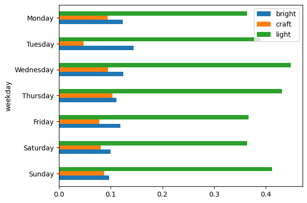

```python
ufo['weekday'] = pd.Categorical(ufo.weekday,['Monday','Tuesday','Wednesday','Thursday','Friday','Saturday','Sunday'])

ufo\
.groupby(['weekday'], observed = False)[['bright','craft','light']]\
.mean()\
.reset_index()\
.sort_index(ascending = False)\
.plot(x = 'weekday', kind = 'barh')
plt.show()
```

## Transforming Numeric Variables

Numeric variables can take on values along a continuum and meaningful arithmetic can be performed. Other labels used to characterize this type of data include quantitative variable, and metric variable.

### Fastfood Data

```python
fastfood = pd.read_csv("fastfood.csv")
fastfood.head()
```

|  | id | health1 | health2 | health3 | mcdonalds | chipotle | shake_shack | gender | age | marital_status | location | duration | rank_chipotle | rank_mcdonalds | rank_shake_shack |
| --- | --- | --- | --- | --- | --- | --- | --- | --- | --- | --- | --- | --- | --- | --- | --- |
| 0 | 1 | 1 | 1 | 1 | 6 | 7 | 3 | Male | 18-29 | never married | Manhattan | 119.338299 | 3 | 2 | 1 |
| 1 | 2 | 6 | 3 | 5 | 5 | 7 | 4 | Female | 50-59 | never married | New Jersey | 221.970589 | 3 | 2 | 1 |
| 2 | 3 | 4 | 3 | 4 | 4 | 2 | 7 | Female | 30-39 | never married | Brooklyn | 260.713333 | 1 | 2 | 3 |
| 3 | 4 | 1 | 1 | 1 | 1 | 4 | 3 | Male | 40-49 | married | Brooklyn | 146.267609 | 3 | 1 | 2 |
| 4 | 5 | 1 | 1 | 1 | 7 | 3 | 1 | Female | 30-39 | never married | Brooklyn | 235.987555 | 2 | 3 | 1 |

### Low Variance

Variables that have zero variance have no predictive power, therefore should be eliminated. But, even variables that have variance close to zero should be candidates for exclusion as they have limited predictive power. Another reason to drop variables with low variance is that in analyses involving resampling, such a variable may end up with zero variance in one of the samples.

The following illustration filters out numeric variables with a variance of less than 0.1.

```python
from sklearn.feature_selection import VarianceThreshold
low_var = VarianceThreshold(threshold=0.1)
fastfood_likert = fastfood.loc[:,'health1':'shake_shack']
fastfood_likert_reduced = low_var.fit_transform(fastfood_likert)
fastfood_likert_reduced
```

```
array([[1, 1, 1, 6, 7, 3],
       [6, 3, 5, 5, 7, 4],
       [4, 3, 4, 4, 2, 7],
       ...,
       [7, 2, 3, 1, 4, 5],
       [4, 1, 1, 3, 3, 7],
       [3, 1, 1, 3, 5, 5]], shape=(2000, 6))
```

### Standardizing

Many machine learning techniques are sensitive to the scale of the variables. Thus, a common pre-processing task is to convert the variables to the same scale. There are a few different approaches to this:

- Min-Max Normalization
- Standardize
- Mean Center

Even though the three health variables are measured on a 1-7 likert scale, their distributions are quite different.

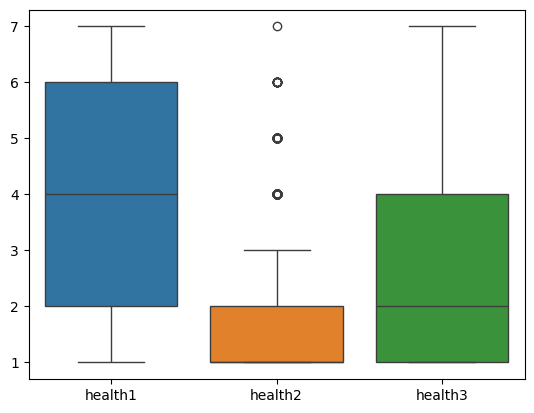

```python
import matplotlib.pyplot as plt
import seaborn as sns
sns.boxplot(fastfood.loc[:,'health1':'health3'])
plt.show()
```

#### Min-Max Normalization

Rescale the features to be between two values

```python
from sklearn.preprocessing import MinMaxScaler
min_max_normal = MinMaxScaler(feature_range=(0,1))
min_max_normal.fit_transform(fastfood.loc[:,'health1':'health3'])
```

```
array([[0.        , 0.        , 0.        ],
       [0.83333333, 0.33333333, 0.66666667],
       [0.5       , 0.33333333, 0.5       ],
       ...,
       [1.        , 0.16666667, 0.33333333],
       [0.5       , 0.        , 0.        ],
       [0.33333333, 0.        , 0.        ]], shape=(2000, 3))
```

#### Standardize

Transform features to have a mean of 0 and standard deviation of 1. This is computed by subtracting mean and dividing by standard deviation.

```python
var_mean = fastfood.loc[:,'health1':'health3'].mean()
var_std = fastfood.loc[:,'health1':'health3'].std()
(fastfood.loc[:,'health1':'health3'] - var_mean)/var_std
```

|  | health1 | health2 | health3 |
| --- | --- | --- | --- |
| 0 | -1.482058 | -0.639555 | -0.938298 |
| 1 | 0.973307 | 1.219616 | 1.513167 |
| 2 | -0.008839 | 1.219616 | 0.900301 |
| 3 | -1.482058 | -0.639555 | -0.938298 |
| 4 | -1.482058 | -0.639555 | -0.938298 |
| ... | ... | ... | ... |
| 1995 | -0.990985 | -0.639555 | -0.938298 |
| 1996 | -0.990985 | -0.639555 | -0.938298 |
| 1997 | 1.464380 | 0.290031 | 0.287434 |
| 1998 | -0.008839 | -0.639555 | -0.938298 |
| 1999 | -0.499912 | -0.639555 | -0.938298 |

2000 rows × 3 columns

Alterantively, use a built-in function.

```python
from sklearn.preprocessing import StandardScaler
standardize = StandardScaler()
standardize.fit_transform(fastfood.loc[:,'health1':'health3'])
```

```
array([[-1.48242914, -0.6397147 , -0.93853305],
       [ 0.97355021,  1.21992106,  1.51354546],
       [-0.00884153,  1.21992106,  0.90052583],
       ...,
       [ 1.46474609,  0.29010318,  0.28750621],
       [-0.00884153, -0.6397147 , -0.93853305],
       [-0.5000374 , -0.6397147 , -0.93853305]], shape=(2000, 3))
```

#### Mean Center

This will move the center to 0 without affecting the variance.

```python
from sklearn.preprocessing import StandardScaler
standardize = StandardScaler(with_std=False)
standardize.fit_transform(fastfood.loc[:,'health1':'health3'])
```

```
array([[-3.018, -0.688, -1.531],
       [ 1.982,  1.312,  2.469],
       [-0.018,  1.312,  1.469],
       ...,
       [ 2.982,  0.312,  0.469],
       [-0.018, -0.688, -1.531],
       [-1.018, -0.688, -1.531]], shape=(2000, 3))
```

### Skewness

A variable with an asymmetric distribution about its mean is skewed. Depending on which side of the mean data is concentrated on, the distribution is described as right skewed (right tail is longer) or left skewed (left tail is longer).

In the fastfood data, histograms indicate chipotle is close to being symmetric while duration is right skewed. This is also borne out by the skewness values - chipotle is close to 0 while duration is much larger than 0.

Skewness can be mitigated by applying a suitable functional transformation such as log, square root, or inverse. However, it is hard to know apriori which type of transformation to apply. Another alternative is to empirically identify an appropriate transformation. Box and Cox transformations are a family of transformation that are indexed by a parameter denoted by lambda. Values of lambda reflect many common transformations such as square (lambda = 2), square root (lambda = 0.5), and inverse (lambda = -1).

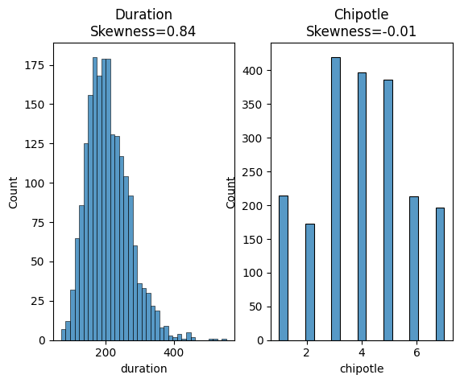

```python
import matplotlib.pyplot as plt
import seaborn as sns
fig, axs = plt.subplots(ncols=2)
sns.histplot(fastfood.duration, ax=axs[0]).set(title="Duration\n"+"Skewness="+str(fastfood.duration.skew().round(2)))
sns.histplot(fastfood.chipotle, ax=axs[1]).set(title="Chipotle\n"+"Skewness="+str(fastfood.chipotle.skew().round(2)))
plt.show()
```

```python
from sklearn.preprocessing import PowerTransformer
box_cox = PowerTransformer('box-cox')
box_cox_duration = box_cox.fit_transform(fastfood.loc[:,['duration']])
box_cox_duration.reshape(2000,)
```

```
array([-1.69425898,  0.3497455 ,  0.90356725, ...,  0.81927213,
       -0.52824732, -1.25885183], shape=(2000,))
```

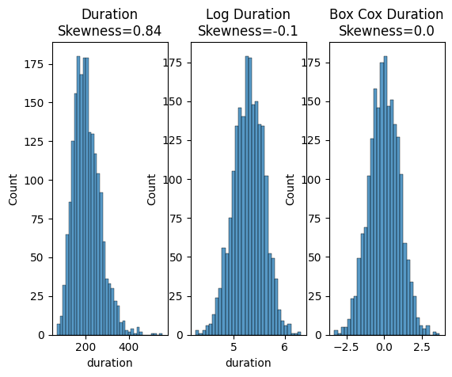

```python
import matplotlib.pyplot as plt
import seaborn as sns
# from scipy import stats
# box_cox_duration, lambda_value = stats.boxcox(fastfood.duration)
from sklearn.preprocessing import PowerTransformer
box_cox = PowerTransformer('box-cox')
box_cox_duration = box_cox.fit_transform(fastfood.loc[:,['duration']]).reshape(2000,)
log_duration = np.log(fastfood.duration)
fig, axs = plt.subplots(ncols=3)
sns.histplot(fastfood.duration, ax=axs[0]).set(title="Duration\n"+"Skewness="+str(fastfood.duration.skew().round(2)))
sns.histplot(log_duration, ax=axs[1]).set(title="Log Duration\n"+"Skewness="+str(log_duration.skew().round(2)))
sns.histplot(box_cox_duration, ax=axs[2]).set(title="Box Cox Duration\n"+"Skewness="+str(pd.Series(box_cox_duration).skew().round(2)))
plt.show()
```

### Polynomial and Interaction Terms

Polynomial and Interaction terms can be generated manually or using Scikit-Learn.

```python
fastfood.loc[:,'health1':'health3'].head()
```

|  | health1 | health2 | health3 |
| --- | --- | --- | --- |
| 0 | 1 | 1 | 1 |
| 1 | 6 | 3 | 5 |
| 2 | 4 | 3 | 4 |
| 3 | 1 | 1 | 1 |
| 4 | 1 | 1 | 1 |

```python
np.vstack((fastfood.health1 **2,
           fastfood.health2 **3,
           fastfood.health3 **2,
           fastfood.health1 * fastfood.health2)).T
```

```
array([[ 1,  1,  1,  1],
       [36, 27, 25, 18],
       [16, 27, 16, 12],
       ...,
       [49,  8,  9, 14],
       [16,  1,  1,  4],
       [ 9,  1,  1,  3]], shape=(2000, 4))
```

```python
from sklearn.preprocessing import PolynomialFeatures
poly_features = PolynomialFeatures(degree = 2, include_bias=False, interaction_only=False)
poly_features.fit_transform(fastfood.loc[:,'health1':'health2'])
```

```
array([[ 1.,  1.,  1.,  1.,  1.],
       [ 6.,  3., 36., 18.,  9.],
       [ 4.,  3., 16., 12.,  9.],
       ...,
       [ 7.,  2., 49., 14.,  4.],
       [ 4.,  1., 16.,  4.,  1.],
       [ 3.,  1.,  9.,  3.,  1.]], shape=(2000, 5))
```

### Outliers

Extreme observations can have an oversized effect on the data. If these extreme observations are caused by errors or unusual responses, then these can be dropped. Such a judgement must be made after carefully examining the outliers.

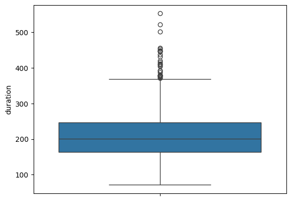

```python
sns.boxplot(fastfood.duration)
plt.show()
```

```python
fastfood_without_duration_outliers = fastfood.loc[fastfood.duration < fastfood.duration.quantile(0.99),:]
```

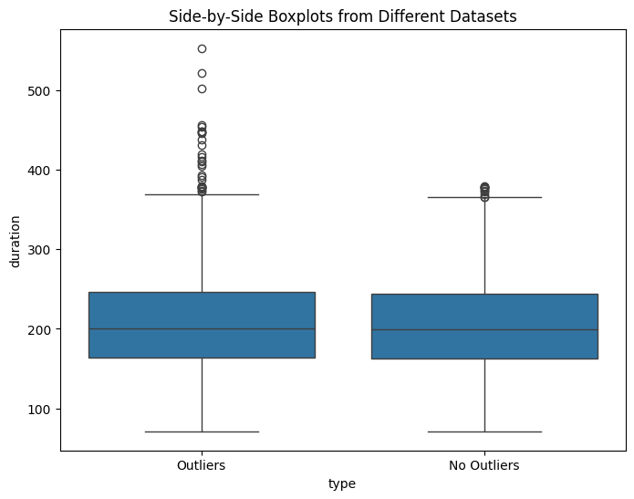

```python
outliers = pd.DataFrame({'type': 'Outliers', 'duration': fastfood.duration})
no_outliers = pd.DataFrame({'type': 'No Outliers', 'duration': fastfood_without_duration_outliers.duration})
df_combined = pd.concat([outliers, no_outliers],ignore_index=True)
plt.figure(figsize=(8, 6))
sns.boxplot(x='type', y='duration', data=df_combined)
plt.title('Side-by-Side Boxplots from Different Datasets')
plt.show()
```

### Binarizing

There may be situations where one may want to convert a numeric data into a binary variable.

```python
fastfood['duration_binary'] = (fastfood.duration>np.median(fastfood.duration)).astype('int32')
fastfood.duration_binary
```

```
0       0
1       1
2       1
3       0
4       1
       ..
1995    1
1996    1
1997    1
1998    0
1999    0
Name: duration_binary, Length: 2000, dtype: int32
```

### Binning

Another common transformation is to group a numeric variable into multiple categories. This may be done to help with interpretation or to construct a visualization such as a histogram.

```python
fastfood['duration_bins'] = pd.cut(fastfood.duration, bins = 5, labels=[1,2,3,4,5])
fastfood['duration_equal_bins'] = pd.qcut(fastfood.duration, q = 5, labels=[1,2,3,4,5])
```

```python
fastfood.duration_bins.head(10)
```

```
0    1
1    2
2    2
3    1
4    2
5    2
6    2
7    2
8    1
9    1
Name: duration_bins, dtype: category
Categories (5, int64): [1 < 2 < 3 < 4 < 5]
```

```python
fastfood.duration_bins.value_counts()
```

```
duration_bins
2    1097
1     558
3     309
4      33
5       3
Name: count, dtype: int64
```

```python
fastfood.duration_equal_bins.value_counts()
```

```
duration_equal_bins
1    400
2    400
3    400
4    400
5    400
Name: count, dtype: int64
```

## Summary

This note examined a number of feature engineering techniques applicable to categorical and numeric features.

This file was generated using Python 3.13.5 on Windows 10 with the following libraries: matplotlib 3.10.3, numpy 2.3.1, pandas 2.3.0, scikit-learn 1.7.1, seaborn 0.13.2